# Projekt Zaliczeniowy - Modele Nieparametryczne

Hanna Sopala

Iga Bochniak

2026-02-11

# Zbiór danych

Zbiór zawiera dane dotyczące płatności/transakcji kartowych z podziałem na transakcje inicjalizujące i rekurencyjne. Baza została stworzona jako transakcje rekurencyjne dokonane między 8 lipca 2020 r. a 7 lipca 2021 r., pod warunkiem, że transakcja inicjalizująca miała miejsce nie wcześniej niż 8 stycznia 2020 r. W zbiorze danych znajdują się następujące zmienne.

| Zmienna | Opis |
| --- | --- |
| `id` | Numer identyfikacyjny konkretnej operacji |
| `initialtransaction_id` | Powiązanie z pierwszą transakcją (moment rejestracji karty) |
| `createtime` | Moment zarejestrowania płatności w systemie |
| `amount` | Kwota przelewu |
| `browseragent` | Dane o przeglądarce, z której korzystał płacący |
| `description` | Tytuł transakcji |
| `recurringaction` | Informacja o rodzaju płatności rekurencyjnej |
| `screenheight` | Wysokość ekranu urządzenia klienta |
| `screenwidth` | Szerokość ekranu urządzenia klienta |
| `acquirerconnectionmethod` | Sposób połączenia z systemem rozliczeniowym. |
| `expirymonth` | Miesiąc, w którym kończy się ważność karty. |
| `expiryyear` | Rok ważności karty |
| `issuer` | Organizacja wystawiająca kartę |
| `type` | Rodzaj karty |
| `level` | Standard karty (np. klasyczna, złota) |
| `countrycode` | Kod państwa, w którym wydano kartę |
| `listtype` | Sektor działania partnera |
| `mccname` | Opis branży sprzedawcy |
| `payclickedtime` | Data i czas potwierdzenia transakcji przez klienta po uzupełnieniu danych kartowych |
| `status` | Status płatności |

Celem niniejszego projektu jest opracowanie modeli predykcyjnych pozwalających na klasyfikację skuteczności transakcji rekurencyjnych oraz prognozowanie ich wartości na podstawie danych o płatnościach kartowych. Jako zmienne zależne wybrano `amount` (regresja) oraz `status` (klasyfikacja).

# Wstępna eksploracja danych

## Wymiary zbiorów danych

```
## Wymiary zbioru uczącego: 29412 20
```

```
## Wymiary zbioru testowego: 15185 19
```

Zbiór uczący liczy 29 412 obserwacji, natomiast zbiór testowy obejmuje 15 185 rekordów.

**Podsumowanie zmiennych w zbiorze uczącym**

```
##        id         initialtransaction_id   createtime
##  Min.   :    17   Min.   :    17        Min.   :2020-01-09 00:07:19.93
##  1st Qu.: 43403   1st Qu.:  1673        1st Qu.:2020-10-23 11:28:57.19
##  Median : 81757   Median : 25840        Median :2021-01-30 07:07:54.65
##  Mean   : 81363   Mean   : 37567        Mean   :2021-01-18 22:17:09.17
##  3rd Qu.:120964   3rd Qu.: 64465        3rd Qu.:2021-04-27 10:53:33.77
##  Max.   :162463   Max.   :162231        Max.   :2021-07-07 23:51:06.22
##                   NA's   :3961
##      amount        browseragent       description        recurringaction
##  Min.   :   0.81   Length:29412       Length:29412       Length:29412
##  1st Qu.:  15.00   Class :character   Class :character   Class :character
##  Median :  30.00   Mode  :character   Mode  :character   Mode  :character
##  Mean   :  59.66
##  3rd Qu.:  50.00
##  Max.   :3450.58
##
##  screenheight       screenwidth        acquirerconnectionmethod  expirymonth
##  Length:29412       Length:29412       Length:29412             Min.   : 1.0
##  Class :character   Class :character   Class :character         1st Qu.: 3.0
##  Mode  :character   Mode  :character   Mode  :character         Median : 7.0
##                                                                 Mean   : 6.5
##                                                                 3rd Qu.: 9.0
##                                                                 Max.   :12.0
##
##    expiryyear      issuer              type              level
##  Min.   :2020   Length:29412       Length:29412       Length:29412
##  1st Qu.:2022   Class :character   Class :character   Class :character
##  Median :2023   Mode  :character   Mode  :character   Mode  :character
##  Mean   :2023
##  3rd Qu.:2024
##  Max.   :2029
##
##  countrycode          listtype           mccname
##  Length:29412       Length:29412       Length:29412
##  Class :character   Class :character   Class :character
##  Mode  :character   Mode  :character   Mode  :character
##
##
##
##
##  payclickedtime                                      status
##  Min.   :2020-01-09 00:09:12.56   bank declined         :   42
##  1st Qu.:2020-07-16 13:30:03.16   card limit exceeded   : 4618
##  Median :2020-11-12 17:09:25.72   do not honor          :  404
##  Mean   :2020-11-06 16:49:59.89   completed successfully:20387
##  3rd Qu.:2021-03-06 07:39:37.21   NA's                  : 3961
##  Max.   :2021-07-07 15:34:35.88
##  NA's   :25451
```

**Podsumowanie zmiennych w zbiorze testowym**

```
##        id         initialtransaction_id   createtime
##  Min.   :     1   Min.   :     1        Min.   :2020-01-08 01:53:59.92
##  1st Qu.: 46869   1st Qu.:  2122        1st Qu.:2020-10-31 14:03:31.66
##  Median : 80559   Median : 29200        Median :2021-01-27 13:43:25.07
##  Mean   : 82061   Mean   : 37889        Mean   :2021-01-21 03:52:11.18
##  3rd Qu.:120269   3rd Qu.: 58451        3rd Qu.:2021-04-26 08:15:43.74
##  Max.   :162456   Max.   :162175        Max.   :2021-07-07 23:28:02.15
##                   NA's   :1698
##      amount        browseragent       description        recurringaction
##  Min.   :   1.00   Length:15185       Length:15185       Length:15185
##  1st Qu.:   1.00   Class :character   Class :character   Class :character
##  Median :   1.00   Mode  :character   Mode  :character   Mode  :character
##  Mean   :  40.17
##  3rd Qu.:  10.00
##  Max.   :3585.49
##  NA's   :13487
##  screenheight       screenwidth        acquirerconnectionmethod
##  Length:15185       Length:15185       Length:15185
##  Class :character   Class :character   Class :character
##  Mode  :character   Mode  :character   Mode  :character
##
##
##
##
##   expirymonth       expiryyear      issuer              type
##  Min.   : 1.000   Min.   :2020   Length:15185       Length:15185
##  1st Qu.: 3.000   1st Qu.:2022   Class :character   Class :character
##  Median : 7.000   Median :2023   Mode  :character   Mode  :character
##  Mean   : 6.298   Mean   :2023
##  3rd Qu.: 9.000   3rd Qu.:2024
##  Max.   :12.000   Max.   :2029
##
##     level           countrycode          listtype           mccname
##  Length:15185       Length:15185       Length:15185       Length:15185
##  Class :character   Class :character   Class :character   Class :character
##  Mode  :character   Mode  :character   Mode  :character   Mode  :character
##
##
##
##
##  payclickedtime
##  Min.   :2020-01-08 01:54:25.23
##  1st Qu.:2020-07-15 19:58:26.25
##  Median :2020-11-09 08:55:10.54
##  Mean   :2020-11-02 18:43:58.34
##  3rd Qu.:2021-02-22 18:15:45.75
##  Max.   :2021-07-07 13:50:28.94
##  NA's   :13487
```

W obu zbiorach występuje po ok. 20 zmiennych opisujących charakterystykę transakcji, przy czym zbiór testowy jest pozbawiony zmiennej celu `status`. Wstępna analiza wskazuje na liczne braki danych w kolumnach `initialtransaction_id` oraz `payclickedtime`.

## Czyszczenie danych

W celu identyfikacji niestandardowych oznaczeń braków danych przeprowadzono analizę unikalnych wartości zmiennych kategorycznych.

**Unikalne wartości w próbie uczącej**

```
## ------------------------------------------------------
## Zmienna: description
## Wartości:
##  [1] ""
##  [2] " platnosci za faktury za tv internet telefon"
##  [3] "Bez ograniczen"
##  [4] "iTaxi"
##  [5] "Orange Flex:"
##  [6] "Orange On-line:"
##  [7] "PLAY - faktura"
##  [8] "PLAY - FAKTURA"
##  [9] "PLAY - weryfikacja"
## [10] "Przejazd A4Go"
## [11] "RecurringPaymentActivation"
## [12] "RedBull Mobile - faktura"
## [13] "RedBull Mobile - FAKTURA"
## [14] "RedBull Mobile - weryfikacja"
## [15] "Szybkie sprawdzanie"
## [16] "Szybkie sprawdzanie firmy"
## [17] "Weryfikacja karty"
## [18] "Zaplata za Ogolnopolskie Biuro Rachunkowe"
## [19] "Zaplata za Ogolnopolskie Biuro Rachunkowe plan prepaid"
##
## ------------------------------------------------------
## Zmienna: recurringaction
## Wartości:
## [1] "AUTO"              "INIT_WITH_PAYMENT" "INIT_WITH_REFUND"
##
## ------------------------------------------------------
## Zmienna: screenheight
## Wartości:
##   [1] "1000" "1002" "1004" "1011" "1024" "1025" "1043" "1050" "1051" "1064"
##  [11] "1076" "1080" "1112" "1117" "1120" "1152" "1164" "1180" "1194" "1200"
##  [21] "1235" "1248" "1280" "1286" "1296" "1366" "1440" "1728" "2160" "412"
##  [31] "559"  "568"  "569"  "600"  "607"  "615"  "618"  "640"  "648"  "658"
##  [41] "664"  "667"  "668"  "670"  "672"  "676"  "686"  "693"  "694"  "699"
##  [51] "712"  "720"  "727"  "732"  "736"  "737"  "740"  "747"  "748"  "749"
##  [61] "753"  "757"  "760"  "765"  "768"  "770"  "771"  "780"  "786"  "790"
##  [71] "793"  "797"  "800"  "808"  "810"  "811"  "812"  "813"  "817"  "818"
##  [81] "823"  "830"  "840"  "844"  "845"  "846"  "848"  "851"  "853"  "854"
```

[output cut: 61 more lines]

```
## Wartości:
## [1] "NULL"
## [2] "Restauracja"
## [3] "Sieci komputerowe usługi informacyjne"
## [4] "Sklepy kosmetyczne"
## [5] "Sklepy spożywcze różne"
## [6] "Ubezpieczenia"
## [7] "Usługi biznesowe gdzie indziej nie sklasyfikowane"
##
## ------------------------------------------------------
## Zmienna: status
## Wartości:
## [1] bank declined          card limit exceeded    do not honor
## [4] completed successfully
## 4 Levels: bank declined card limit exceeded ... completed successfully
```

**Unikalne wartości w próbie testowej**

```
## ------------------------------------------------------
## Zmienna: description
## Wartości:
##  [1] ""
##  [2] " platnosci za faktury za tv internet telefon"
##  [3] "Bez ograniczen"
##  [4] "iTaxi"
##  [5] "Orange Flex:"
##  [6] "Orange On-line:"
##  [7] "PLAY - faktura"
##  [8] "PLAY - FAKTURA"
##  [9] "PLAY - weryfikacja"
## [10] "Przejazd A4Go"
## [11] "RecurringPaymentActivation"
## [12] "RedBull Mobile - faktura"
## [13] "RedBull Mobile - FAKTURA"
## [14] "RedBull Mobile - weryfikacja"
## [15] "Szybkie sprawdzanie"
## [16] "Szybkie sprawdzanie firmy"
## [17] "Weryfikacja karty"
## [18] "Zaplata za Ogolnopolskie Biuro Rachunkowe"
##
## ------------------------------------------------------
## Zmienna: recurringaction
## Wartości:
## [1] "AUTO"              "INIT_WITH_PAYMENT" "INIT_WITH_REFUND"
## [4] "MANUAL"
##
## ------------------------------------------------------
## Zmienna: screenheight
## Wartości:
##  [1] "1000" "1022" "1024" "1029" "1050" "1064" "1080" "1112" "1138" "1152"
## [11] "1194" "1200" "1280" "1440" "1692" "2160" "412"  "568"  "569"  "570"
## [21] "640"  "658"  "665"  "667"  "680"  "694"  "699"  "712"  "720"  "732"
## [31] "735"  "736"  "740"  "747"  "748"  "752"  "753"  "756"  "758"  "760"
## [41] "768"  "770"  "771"  "772"  "780"  "785"  "786"  "792"  "797"  "800"
## [51] "811"  "812"  "813"  "816"  "817"  "818"  "823"  "824"  "830"  "833"
## [61] "840"  "844"  "846"  "848"  "851"  "854"  "857"  "858"  "861"  "864"
## [71] "869"  "873"  "877"  "879"  "882"  "883"  "892"  "895"  "896"  "900"
## [81] "902"  "907"  "915"  "918"  "926"  "938"  "942"  "950"  "960"  "962"
```

[output cut: 43 more lines]

```
##
## ------------------------------------------------------
## Zmienna: listtype
## Wartości:
## [1] "ECOMMERCE" "MWF"       "PUBLIC"
##
## ------------------------------------------------------
## Zmienna: mccname
## Wartości:
## [1] "NULL"
## [2] "Restauracja"
## [3] "Sieci komputerowe usługi informacyjne"
## [4] "Sklepy spożywcze różne"
## [5] "Ubezpieczenia"
## [6] "Usługi biznesowe gdzie indziej nie sklasyfikowane"
```

Wstępna analiza jakości danych ujawniła niespójne kodowanie brakujących wartości. Oprócz standardowych wartości `NA`, zidentyfikowano również puste ciągi znaków oraz wartości tekstowe NULL. Wszystkie te wartości zostały poddane rekodowaniu do standardowej wartości NA przed rozpoczęciem modelowania.

### Obsługa braków danych

Niektóre zmienne mają zbyt dużą liczbę braków danych. Zbyt duża liczba brakujących obserwacji może prowadzić do niestabilności modeli lub błędnych wniosków.

W celu identyfikacji takich zmiennych przeprowadzono analizę procentowego udziału wartości NA dla każdego atrybutu.

```
##   browseragent   screenheight    screenwidth payclickedtime
##       86.53271       91.36067       91.36067       86.53271
```

W celu zapewnienia wysokiej jakości danych wejściowych, zastosowano procedurę automatycznej selekcji zmiennych. Obliczono odsetek brakujących wartości dla każdego atrybutu w zbiorze uczącym. Zmienne, w których braki danych przekraczały próg 50% `browseragent`, `screenheight`, `screenwidth`, `payclickedtime`, zostały trwale usunięte z obu zbiorów (uczącego i testowego). Pozwoliło to uniknięcie błędów w modelach nieobsługujących dużej liczby braków.

Zrezygnowano z imputacji braków danych, aby uniknąć zniekształcenia pierwotnych rozkładów zmiennych.

### Eliminacja nadmiarowości

W trakcie eksploracji braków danych zidentyfikowano niespójności w zapisie tytułów płatności (zmienna `description`). Te same kategorie były zapisywane w sposób nadmiarowy, różniąc się jedynie wielkością liter (np. “PLAY - faktura” vs “PLAY - FAKTURA” oraz “RedBull Mobile - faktura” vs “RedBull Mobile - FAKTURA”).

W celu wyeliminowania pozornej zmienności przeprowadzono proces ujednolicenia danych. Wszystkie znaki zostały skonwertowane na wielkie litery. Usunięto spacje brzegowe ze względów estetycznych.

**Efekt agregacji zmiennej `description`**

```
##  [1] "BEZ OGRANICZEN"
##  [2] "ITAXI"
##  [3] "ORANGE FLEX:"
##  [4] "ORANGE ON-LINE:"
##  [5] "PLATNOSCI ZA FAKTURY ZA TV INTERNET TELEFON"
##  [6] "PLAY - FAKTURA"
##  [7] "PLAY - WERYFIKACJA"
##  [8] "PRZEJAZD A4GO"
##  [9] "RECURRINGPAYMENTACTIVATION"
## [10] "REDBULL MOBILE - FAKTURA"
## [11] "REDBULL MOBILE - WERYFIKACJA"
## [12] "SZYBKIE SPRAWDZANIE"
## [13] "SZYBKIE SPRAWDZANIE FIRMY"
## [14] "WERYFIKACJA KARTY"
## [15] "ZAPLATA ZA OGOLNOPOLSKIE BIURO RACHUNKOWE"
## [16] "ZAPLATA ZA OGOLNOPOLSKIE BIURO RACHUNKOWE PLAN PREPAID"
```

## Weryfikacja i korekta typów zmiennych

Po wstępnym oczyszczeniu zbioru z braków danych, przeprowadzono analizę typów zmiennych. Zauważono, że część zmiennych numerycznych oraz kategorycznych została błędnie zinterpretowana jako tekst (`character`), co uniemożliwia ich poprawne wykorzystanie w modelach nieparametrycznych.

**Struktura zbioru danych**

```
## 'data.frame':    29412 obs. of  16 variables:
##  $ id                      : int  2783 13177 19604 25072 37463 49995 61735 15088 15135 40452 ...
##  $ initialtransaction_id   : int  17 17 17 17 17 17 17 20 20 20 ...
##  $ createtime              : POSIXct, format: "2020-07-08 23:13:33" "2020-08-08 23:13:48" ...
##  $ amount                  : num  25 25 8 25 25 ...
##  $ description             : chr  "ORANGE ON-LINE:" "ORANGE ON-LINE:" "ORANGE ON-LINE:" "ORANGE ON-LINE:" ...
##  $ recurringaction         : chr  "AUTO" "AUTO" "AUTO" "AUTO" ...
##  $ acquirerconnectionmethod: chr  "FDP_SOAP" "FDP_SOAP" "FDP_SOAP" "FDP_SOAP" ...
##  $ expirymonth             : int  12 12 12 12 12 12 12 12 12 12 ...
##  $ expiryyear              : int  2020 2020 2020 2020 2020 2020 2020 2020 2020 2020 ...
##  $ issuer                  : chr  "VISA" "VISA" "VISA" "VISA" ...
##  $ type                    : chr  "DEBIT" "DEBIT" "DEBIT" "DEBIT" ...
##  $ level                   : chr  "CLASSIC" "CLASSIC" "CLASSIC" "CLASSIC" ...
##  $ countrycode             : chr  "PL" "PL" "PL" "PL" ...
##  $ listtype                : chr  "ECOMMERCE" "ECOMMERCE" "ECOMMERCE" "ECOMMERCE" ...
##  $ mccname                 : chr  "Usługi biznesowe gdzie indziej nie sklasyfikowane" "Usługi biznesowe gdzie indziej nie sklasyfikowane" "Usługi biznesowe gdzie indziej nie sklasyfikowane" "Usługi biznesowe gdzie indziej nie sklasyfikowane" ...
##  $ status                  : chr  "completed successfully" "completed successfully" "completed successfully" "completed successfully" ...
```

Szczególną uwagę poświęcono zmiennej tekstowej `description`. W modelach nieparametrycznych zmienne kategoryczne o bardzo dużej liczbie unikalnych poziomów nie są bowiem wskazane.

Sprawdzono liczbę unikalnych wariantów dla podejrzanej zmiennej:

```
## Liczba wariantów w zmiennej description: 17
```

Analiza wykazała, że zmienna `description`, wbrew początkowym założeniom, przyjmuje jedynie kilkanaście powtarzalnych wartości. Jest to informacja potencjalnie użyteczna dla modelu, dlatego zostanie ona uwzględniona w dalszej analizie jako zmienna kategoryczna (`factor`).

Zmienne `expirymonth` oraz `expiryyear` pozostawiono jako liczby całkowite (`integer`). Decyzja ta podyktowana jest naturą algorytmów drzewiastych, które lepiej radzą sobie z zachowaniem porządku chronologicznego na zmiennych liczbowych niż na nieuporządkowanych faktorach.

**Struktura zbioru danych po naprawie**

```
## 'data.frame':    29412 obs. of  16 variables:
##  $ id                      : int  2783 13177 19604 25072 37463 49995 61735 15088 15135 40452 ...
##  $ initialtransaction_id   : int  17 17 17 17 17 17 17 20 20 20 ...
##  $ createtime              : POSIXct, format: "2020-07-08 23:13:33" "2020-08-08 23:13:48" ...
##  $ amount                  : num  25 25 8 25 25 ...
##  $ description             : Factor w/ 16 levels "BEZ OGRANICZEN",..: 4 4 4 4 4 4 3 NA NA NA ...
##  $ recurringaction         : Factor w/ 3 levels "AUTO","INIT_WITH_PAYMENT",..: 1 1 1 1 1 1 1 1 1 1 ...
##  $ acquirerconnectionmethod: Factor w/ 2 levels "ECARD_REST","FDP_SOAP": 2 2 2 2 2 2 2 2 2 2 ...
##  $ expirymonth             : int  12 12 12 12 12 12 12 12 12 12 ...
##  $ expiryyear              : int  2020 2020 2020 2020 2020 2020 2020 2020 2020 2020 ...
##  $ issuer                  : Factor w/ 3 levels "MAESTRO","MASTERCARD",..: 3 3 3 3 3 3 3 2 2 2 ...
##  $ type                    : Factor w/ 2 levels "CREDIT","DEBIT": 2 2 2 2 2 2 2 2 2 2 ...
##  $ level                   : Factor w/ 31 levels "BLACK","BUSINESS",..: 3 3 3 3 3 3 3 23 23 23 ...
##  $ countrycode             : Factor w/ 33 levels "AE","AZ","BY",..: 26 26 26 26 26 26 26 26 26 26 ...
##  $ listtype                : Factor w/ 3 levels "ECOMMERCE","MWF",..: 1 1 1 1 1 1 1 2 2 2 ...
##  $ mccname                 : Factor w/ 6 levels "Restauracja",..: 6 6 6 6 6 6 6 6 6 6 ...
##  $ status                  : Factor w/ 4 levels "bank declined",..: 3 3 3 3 3 3 3 3 3 3 ...
```

# Wzbogacanie danych

## Segmentacja transakcji rekurencyjnych

Zgodnie z definicją biznesową, transakcje inicjalizujące (`INIT`) są zawsze udane i służą jedynie do rejestracji metody płatności. Włączenie ich do zbioru uczącego sztucznie zawyżyłoby skuteczność modelu (trywialna predykcja). Celem projektu jest predykcja powodzenia obciążeń **rekurencyjnych** (`AUTO` i `MANUAL`), które niosą ryzyko odrzucenia.

Dlatego dokonano podziału zbioru na:

- **Słownik transakcji inicjalizujących:** Źródło cech o momencie rejestracji karty.
- **Zbiór właściwy (rekurencyjny):** Transakcje podlegające modelowaniu.

```
## Liczba transakcji inicjalizujących w próbie uczącej: 3961
```

```
## Liczba transakcji rekurencyjnych w próbie uczącej: 25451
```

```
## Liczba transakcji inicjalizujących w próbie testowej: 1698
```

```
## Liczba transakcji rekurencyjnych w próbie testowej: 13487
```

## Rekonstrukcja relacji między transakcjami

Wykorzystując klucz `initialtransaction_id`, połączono każdą transakcję rekurencyjną z odpowiadającą jej transakcją inicjalizującą, aby uzyskać dla niej dodatkowe informacje.

## Definicja zmiennej celu

Dokonano transformacji pierwotnej zmiennej celu (`status`). Zmienna ta została poddana dychotomizacji: wszystkie transakcje o statusie innym niż `completed successfully` zaklasyfikowano jako `porażka`, natomiast pozostałe jako `sukces`.

Kluczowym elementem inżynierii cech było zdefiniowanie porażki jako klasy wyróżnionej (pozytywnej). Jest to podyktowane celem projektu, którym jest identyfikacja transakcji zagrożonych odrzuceniem. Takie ustawienie poziomów czynnika pozwala na bezpośrednią interpretację metryk jakości modelu, w szczególności F-miary.

## Inżynieria cech czasowych

W celu uwzględnienia cykliczności zachowań płatniczych oraz specyfiki systemów bankowych, dokonano dekompozycji zmiennej czasowej `createtime`. Na jej podstawie wyznaczono godzinę oraz dzień tygodnia transakcji, zachowując ich chronologiczny porządek. Dodatkowo wprowadzono zmienne binarne identyfikujące transakcje weekendowe oraz te realizowane w godzinach nocnych (00:00–05:00), które są szczególnie narażone na niepowodzenie ze względu na potencjalne przerwy techniczne po stronie wystawców kart.

```
##  [1] "id"                       "initialtransaction_id"
##  [3] "createtime"               "amount"
##  [5] "description"              "recurringaction"
##  [7] "acquirerconnectionmethod" "expirymonth"
##  [9] "expiryyear"               "issuer"
## [11] "type"                     "level"
## [13] "countrycode"              "listtype"
## [15] "mccname"                  "status"
## [17] "time_init"                "status_bin"
## [19] "hour"                     "week_day"
## [21] "week_part"                "day_part"
```

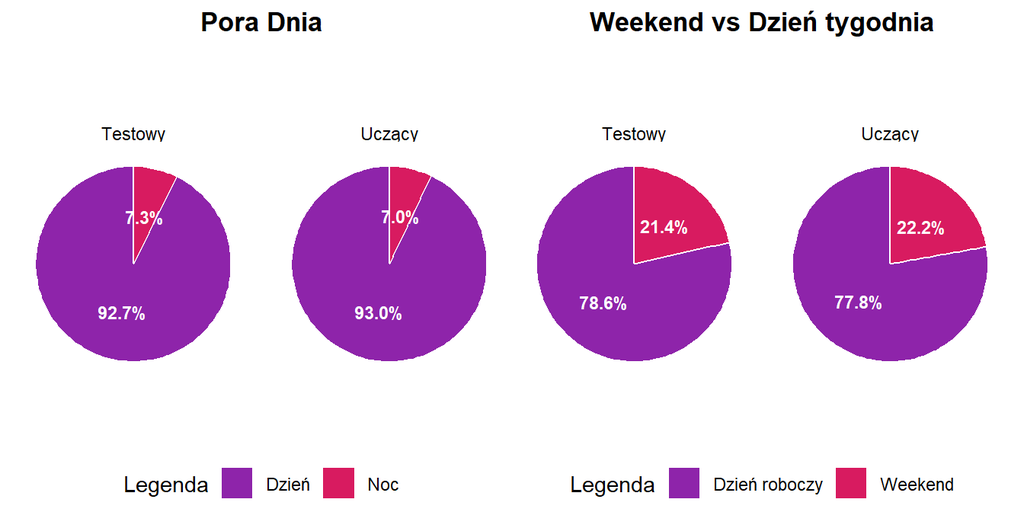

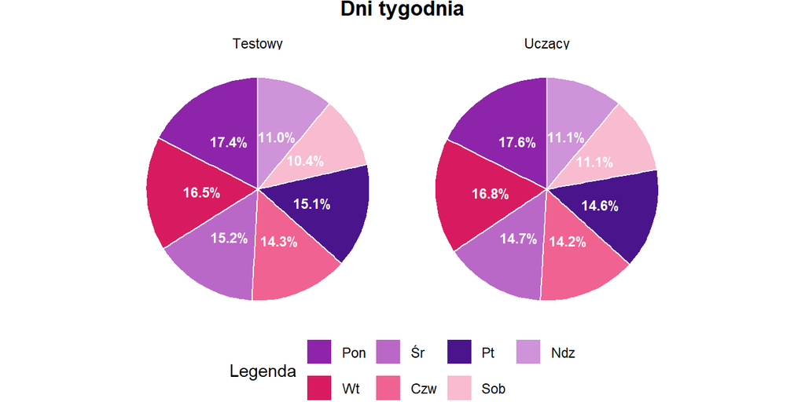

## Charakterystyka karty

### Wiek karty w systemie

Połączenie każdej transakcję rekurencyjną z odpowiadającą jej transakcją inicjalizującą pozwoliło na wygenerowanie nowej zmiennej: `days_since_init`. Zmienna ta reprezentuje liczbę dni, jaka upłynęła od momentu rejestracji karty (`time_init`) do momentu bieżącej transakcji rekurencyjnej (`createtime`), dzięki czemu określono staż danej karty w systemie. Zmienna ta ma na celu sprawdzenie hipotezy, czy karty o dłuższej historii subskrypcyjnej rzadziej generują błędy płatności.

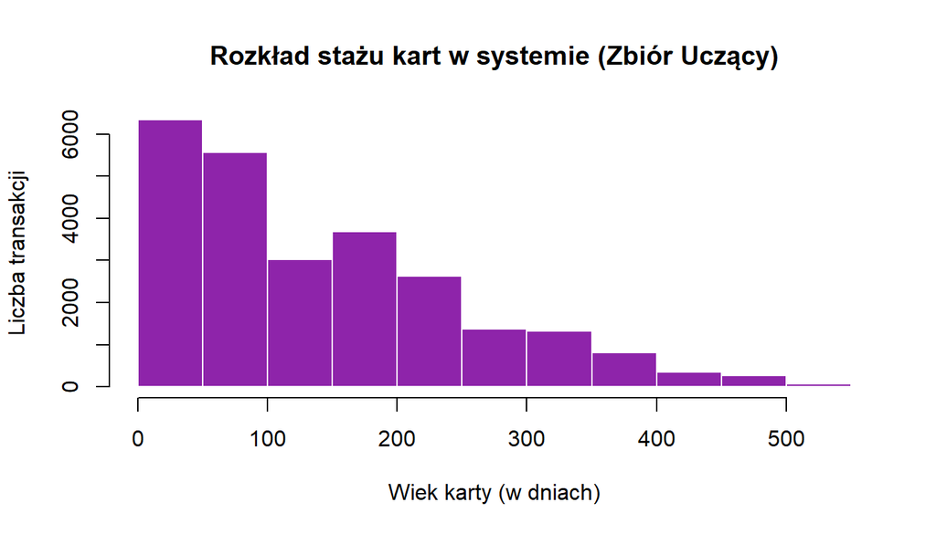

```
##     Min.  1st Qu.   Median     Mean  3rd Qu.     Max.
##   0.0003  50.7949 119.4259 140.5470 211.9597 541.7457
```

### Analiza ważności karty

Wyznaczono liczbę miesięcy pozostałych do wygaśnięcia karty oraz stworzono zmienną dychotomiczną identyfikującą transakcje dokonane w roku utraty ważności. Informacja ta jest kluczowa dla modelu klasyfikacji, gdyż zbliżający się termin ważności karty może być przyczyną odrzuceń płatności przez wystawcę.

```
## Minimum liczby miesięcy ważności karty na zbiorze uczącym: -1.203226
```

```
## Minimum liczby miesięcy ważności karty na zbiorze testowym: -1.197124
```

Analiza zmiennej `months_to_expire` wykazała obecność wartości ujemnych. Zjawisko to interpretowane jest jako próba realizacji transakcji przy użyciu karty, której termin ważności upłynął przed datą obciążenia.

```
## Liczba kart przeterminowanych w zbiorze uczącym: 196 (0.77%)
```

```
## Liczba kart przeterminowanych w zbiorze testowym: 178 (1.32%)
```

Karty przeterminowane stanowią niewielki odsetek analizowanych danych.

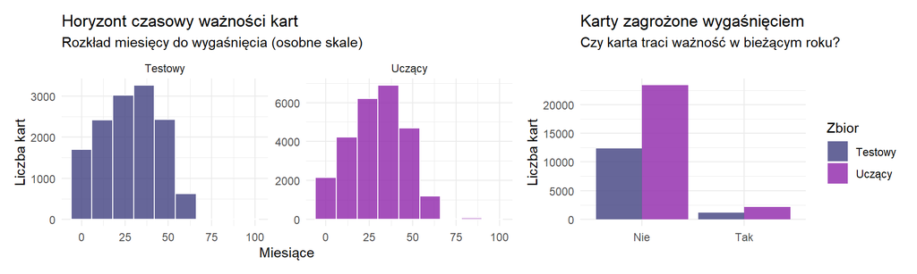

### Pochodzenie karty

Dokonano segmentacji transakcji na krajowe oraz zagraniczne na podstawie kodu kraju wydawcy karty (`countrycode`). Wprowadzenie tego podziału pozwala na ocenę wpływu potencjalnych blokad antyfraudowych stosowanych przez zagraniczne instytucje finansowe na skuteczność płatności.

Struktura pochodzenia kart w zbiorze uczącym

| Pochodzenie karty | Liczba | Udział % |
| --- | --- | --- |
| Krajowa | 23192 | 91.12 |
| Zagraniczna | 2259 | 8.88 |

# Budowanie modeli

## Wybór zmiennych do modelowania

W celu zapewnienia przejrzystości procesu modelowania oraz uniknięcia problemów z przeuczeniem przeprowadzono selekcję cech. Proces ten oparto na analizie liczby unikalnych poziomów każdej zmiennej.

**Liczba unikalnych poziomów każdej zmiennej**

```
##                           [,1]
## recurringaction              1
## acquirerconnectionmethod     2
## type                         2
## status_bin                   2
## week_part                    2
## day_part                     2
## expires_this_year            2
## card_origin                  2
## issuer                       3
## listtype                     3
## status                       4
## mccname                      7
## week_day                     7
## expiryyear                  10
## description                 11
## expirymonth                 12
## hour                        24
## level                       31
## countrycode                 33
## expirydate                  80
## amount                    2338
## initialtransaction_id     3961
## time_init                 3961
## createtime               25450
## days_since_init          25450
## months_to_expire         25450
## id                       25451
```

Do dalszych etapów zakwalifikowano zmienne kategoryczne posiadające od 2 do 25 unikalnych poziomów oraz kluczowe zmienne numeryczne. Pozwoli to na budowę czytelnych drzew decyzyjnych, eliminując jednocześnie szum informacyjny.

## Podział zbioru uczącego

W celu rzetelnej weryfikacji jakości budowanych modeli oraz uniknięcia zjawiska przeuczenia (overfitting), pierwotny zbiór danych (`uczaca_rekurencyjne`) został podzielony na dwie niezależne podpróby. Ponieważ udostępniony zbiór testowy (`proba_testowa`) nie posiada etykiet zmiennej celu, konieczne było wyodrębnienie własnego zestawu danych do bieżącej ewaluacji.

Zastosowano losowy dobór próby w następujących proporcjach:

- Zbiór treningowy (70% obserwacji): wykorzystywany do konstrukcji i uczenia modeli.
- Zbiór walidacyjny (30% obserwacji): służący do strojenia parametrów (np. przycinania drzewa), wyboru optymalnego modelu oraz oceny skuteczności predykcji (na podstawie F-miary i błędów).

Aby zapewnić pełną powtarzalność uzyskanych wyników, ustawiono ziarno generatora liczb losowych na wartość odpowiadającą sumie numerów albumów autorek projektu. Przeprowadzono również weryfikację rozkładu zmiennej celu w obu podzbiorach, aby potwierdzić reprezentatywność wylosowanych prób.

```
## Proporcja 'sukces' w całym zbiorze:
```

```
##
##   porażka    sukces
## 0.1989706 0.8010294
```

```
##
## Proporcja 'sukces' w zbiorze treningowym:
```

```
##
##   porażka    sukces
## 0.1994387 0.8005613
```

```
##
## Proporcja 'sukces' w zbiorze walidacyjnym:
```

```
##
##   porażka    sukces
## 0.1978785 0.8021215
```

## Klasyfikacja (`status`)

Celem tego etapu jest zbudowanie modelu drzewa decyzyjnego, który przewidzi, czy transakcja rekurencyjna zakończy się sukcesem, czy porażką. Zgodnie z założeniami projektu, zdefiniowano klasę `porażka` jako pozytywną (kluczową do wykrycia).

### Budowa drzewa maksymalnego

Przed przystąpieniem do konstrukcji modelu, zdefiniowano warunek w postaci minimalnej liczebności węzła końcowego (minbucket). Aby zapewnić istotność statystyczną wyodrębnionych reguł i uniknąć tworzenia gałęzi dla pojedynczych przypadków (co prowadziłoby do trywialnego przeuczenia), przyjęto próg wynoszący 1% liczebności zbioru treningowego.

```
## Ustawienie minbucket na: 178
```

Oznacza to, że każdy liść drzewa musi reprezentować grupę co najmniej 178 transakcji.

W pierwszym etapie modelowania zbudowano tzw. drzewo maksymalne. Zastosowano algorytm CART z parametrem złożoności `cp = 0`, co pozwoliło na swobodny podział przestrzeni cech aż do momentu spełnienia warunku minbucket. Celem tego kroku jest wygenerowanie modelu o niskim obciążeniu, który wychwyci nawet subtelne zależności w danych, godząc się tymczasowo na wysoką wariancję i ryzyko nadmiernego dopasowania.

Poniższy diagram przedstawia strukturę wygenerowanego drzewa maksymalnego. Ze względu na brak ograniczeń w przyroście głębokości (poza minbucket), model ten charakteryzuje się wysokim stopniem skomplikowania, co utrudnia jego interpretację i sugeruje konieczność optymalizacji w celu poprawy zdolności generalizacji na nowych danych.

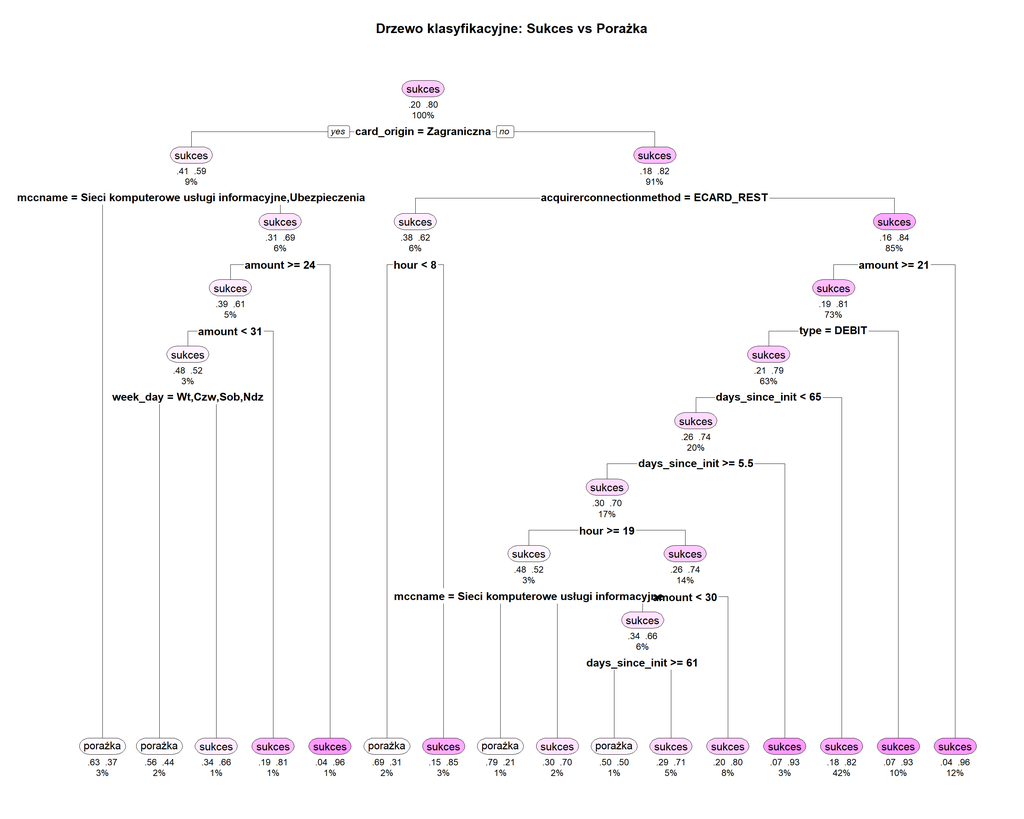

Analiza struktury drzewa maksymalnego pozwala na identyfikację kluczowych segmentów ryzykownych:

- Pochodzenie karty głównym podziałem: najważniejszą zmienną różnicującą jest card_origin. Karty zagraniczne charakteryzują się znacznie wyższym bazowym ryzykiem odrzucenia (ok. 41%) w porównaniu do kart krajowych (ok. 18%).
- Wśród kart zagranicznych, transakcje realizowane w kategoriach MCC: Sieci komputerowe / usługi informacyjne oraz Ubezpieczenia, są obarczone bardzo wysokim ryzykiem.
- Dla kart krajowych istotna okazała się metoda połączenia ECARD_REST. W tej grupie występuje silna zależność od pory dnia - transakcje realizowane w godzinach nocnych i wczesnoporannych (przed 7:30) mają większe prawdopodobieństwa niepowodzenia, co może sugerować przerwy serwisowe lub specyficzne okna fraudowe.

### Optymalizacja (przycinanie) drzewa

Kluczowym etapem budowy drzewa decyzyjnego jest jego przycięcie, mające na celu redukcję wariancji modelu. W tym celu przeanalizowano zależność między parametrem złożoności (`CP`) a błędem walidacji krzyżowej (`xerror`).

Wykres osypiska obrazuje, jak zmienia się błąd predykcji wraz ze wzrostem wielkości drzewa.

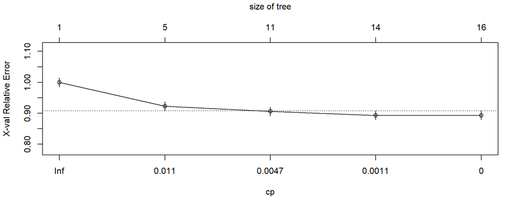

Do wyboru ostatecznej struktury modelu zastosowano regułę jednego błędu standardowego. Zgodnie z tą metodyką, nie wybiera się drzewa o absolutnie najmniejszym błędzie walidacji (które może być niestabilne), lecz najprostsze drzewo, którego błąd mieści się w podanym zakresie. Podejście to pozwala uzyskać model bardziej konserwatywny, odporniejszy na szum w danych i lepiej generalizujący wyniki na zbiorze testowym.

```
## Wybrane optymalne CP: 0.00403415
```

Na podstawie wyznaczonego parametru `cp_optymalne` dokonano przycięcia drzewa maksymalnego, usuwając gałęzie nie wnoszące istotnej poprawy jakości klasyfikacji.

Poniżej przedstawiono wizualizację optymalnego drzewa decyzyjnego. Uzyskany model charakteryzuje się mniejszą liczbę węzłów niż drzewo maksymalne, co przekłada się na czytelniejsze reguły decyzyjne. Węzły końcowe (liście) zawierają informację o dominującej klasie (`sukces` lub `porażka`), prawdopodobieństwie przynależności do tej klasy oraz odsetku obserwacji trafiających do danego segmentu.

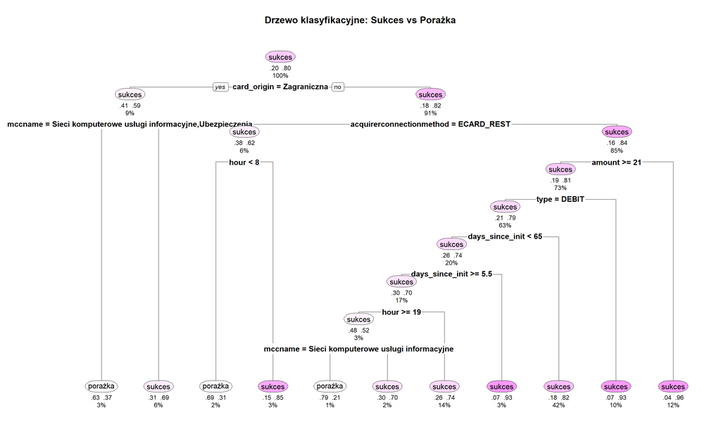

**Reguły w drzewie przyciętym**

```
##  status_bin                                                                                                                                                                                                                                                                    cover
##        0.21 when card_origin is     Krajowa & acquirerconnectionmethod is   FDP_SOAP & amount >= 21 & type is  DEBIT & hour >= 18.5 & days_since_init is 5.5 to 64.6 & mccname is                                                      Sieci komputerowe usługi informacyjne      1%
##        0.31 when card_origin is     Krajowa & acquirerconnectionmethod is ECARD_REST                                 & hour <   7.5                                                                                                                                               2%
##        0.37 when card_origin is Zagraniczna                                                                                                                          & mccname is                                     Sieci komputerowe usługi informacyjne or Ubezpieczenia      3%
##        0.69 when card_origin is Zagraniczna                                                                                                                          & mccname is Restauracja or Sklepy spożywcze różne or Usługi biznesowe gdzie indziej nie sklasyfikowane      6%
##        0.70 when card_origin is     Krajowa & acquirerconnectionmethod is   FDP_SOAP & amount >= 21 & type is  DEBIT & hour >= 18.5 & days_since_init is 5.5 to 64.6 & mccname is                                          Usługi biznesowe gdzie indziej nie sklasyfikowane      2%
##        0.74 when card_origin is     Krajowa & acquirerconnectionmethod is   FDP_SOAP & amount >= 21 & type is  DEBIT & hour <  18.5 & days_since_init is 5.5 to 64.6                                                                                                             14%
##        0.82 when card_origin is     Krajowa & acquirerconnectionmethod is   FDP_SOAP & amount >= 21 & type is  DEBIT                & days_since_init >=        64.6                                                                                                             42%
##        0.85 when card_origin is     Krajowa & acquirerconnectionmethod is ECARD_REST                                 & hour >=  7.5                                                                                                                                               3%
##        0.93 when card_origin is     Krajowa & acquirerconnectionmethod is   FDP_SOAP & amount >= 21 & type is CREDIT                                                                                                                                                             10%
##        0.93 when card_origin is     Krajowa & acquirerconnectionmethod is   FDP_SOAP & amount >= 21 & type is  DEBIT                & days_since_init <  5.5                                                                                                                      3%
##        0.96 when card_origin is     Krajowa & acquirerconnectionmethod is   FDP_SOAP & amount <  21                                                                                                                                                                              12%
```

Analiza struktury wygenerowanego drzewa decyzyjnego pozwoliła na precyzyjną identyfikację warunków, w których ryzyko niepowodzenia transakcji jest najwyższe. Najbardziej newralgiczną grupę, obarczoną aż 79-procentowym ryzykiem błędu, stanowią operacje realizowane krajowymi kartami debetowymi w godzinach wieczornych, dotyczące płatności za usługi komputerowe lub sieciowe.

Istotnym czynnikiem ryzyka okazała się również pora realizacji przelewu w połączeniu z metodą procesowania. Transakcje krajowe obsługiwane przez system ECARD_REST, zlecane w godzinach nocnych oraz wczesnoporannych (przed 07:30), kończą się niepowodzeniem w blisko 69% przypadków, co może sugerować występowanie cyklicznych przerw technicznych lub okien serwisowych po stronie operatora.

Trzeci zidentyfikowany obszar ryzyka dotyczy płatności międzynarodowych. W sytuacji, gdy karty zagraniczne wykorzystywane są do opłacenia składek ubezpieczeniowych lub usług informatycznych, skuteczność transakcji spada, a ryzyko odrzucenia wynosi około 63%. Wynika to prawdopodobnie z restrykcyjnej polityki antyfraudowej banków, które częściej blokują transakcje zagraniczne w tych konkretnych kategoriach usług.

### Ewaluacja modelu na zbiorze walidacyjnym

W celu ostatecznej weryfikacji jakości zbudowanego modelu, przeprowadzono predykcję na niezależnym zbiorze walidacyjnym. Pozwala to ocenić, czy model nie uległ przeuczeniu i jak radzi sobie z klasyfikacją nowych obserwacji.

Kluczowym narzędziem oceny jest macierz pomyłek, która zestawia decyzje modelu z rzeczywistym statusem transakcji.

Macierz pomyłek dla zbioru walidacyjnego

|  | porażka | sukces |
| --- | --- | --- |
| porażka | 324 | 1187 |
| sukces | 160 | 5965 |

Na podstawie powyższej macierzy wyznaczono kluczowe współczynniki jakości klasyfikacji, przyjmując klasę `porażka` jako pozytywną:

- Precyzja: Jaki odsetek transakcji uznanych przez model za porażki, faktycznie nimi był?
- Czułość: Jaki odsetek wszystkich rzeczywistych porażek udało się wykryć?
- F-miara: Średnia harmoniczna precyzji i czułości (kluczowa miara w przypadku niezbalansowanych klas).

Miary oceny modelu dla klasy ‘porażka’

| Metryka | Wartość |
| --- | --- |
| Dokładność | 0.8236 |
| Precyzja | 0.6694 |
| Czułość | 0.2144 |
| F-miara | 0.3248 |

Analiza uzyskanych metryk pozwala na szczegółową ocenę zdolności predykcyjnych modelu drzewa decyzyjnego:

- Model poprawnie klasyfikuje ponad 82% wszystkich transakcji. Wynik ten jest jednak zdominowany przez liczną klasę `sukces` i w przypadku danych niezbalansowanych nie powinien być jedynym kryterium oceny.
- Gdy model przewiduje, że transakcja zakończy się porażką, ma rację w ok. 67% przypadków. Jest to satysfakcjonujący wynik, oznaczający, że model generuje stosunkowo mało fałszywych alarmów.
- Czułość to najsłabszy punkt modelu. Algorytm identyfikuje jedynie co piątą rzeczywistą porażkę (21%). Oznacza to, że model jest bardzo konserwatywny - woli przypisać transakcję do klasy większościowej (`sukces`), niż ryzykować błąd.
- Niska wartość F-miary jest bezpośrednią konsekwencją niskiej czułości. Wskazuje to, że podstawowy model drzewa decyzyjnego ma trudności z wyłapywaniem rzadkich zdarzeń, jakimi są błędy transakcji.

Zbudowany model może służyć jako system wspomagający do filtrowania transakcji o bardzo wysokim ryzyku (tam, gdzie pewność jest duża), jednak nie jest wystarczający do wykrycia wszystkich potencjalnych problemów płatniczych.

## Regresja (`amount`)

### Analiza rozkładu zmiennej celu (`amount`)

Wstępna eksploracja zmiennej objaśnianej amount wykazała silną asymetrię prawostronną rozkładu. Zdecydowana większość transakcji w zbiorze treningowym dotyczy niskich kwot – mediana wynosi 30.00, podczas gdy średnia arytmetyczna jest ponad dwukrotnie wyższa (62.63). Wskazuje to na obecność tzw. długiego ogona dystrybucji.

```
##    Min. 1st Qu.  Median    Mean 3rd Qu.    Max.
##    0.96   25.00   30.00   62.63   50.00 2606.37
```

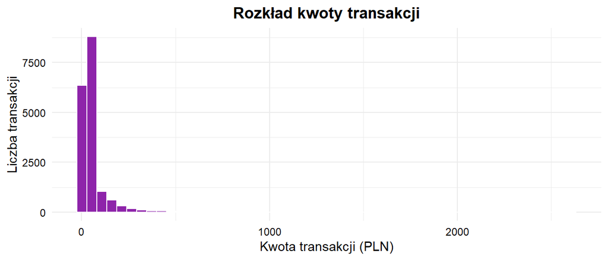

```
## 99% transakcji jest mniejszych niż: 585.53  zł.
```

```
## Liczba wartości ekstremalnych do usunięcia: 179 ( 1 % zbioru )
```

Szczegółowa analiza wartości skrajnych ujawniła, że aż 99% wszystkich obserwacji mieści się w przedziale do 585.53. Powyżej tego progu znajduje się 179 transakcji (stanowiących zaledwie 1% zbioru), z maksymalną zanotowaną kwotą na poziomie 2606.37.

W kontekście budowy drzew regresyjnych, wartości ekstremalne mogą mieć destrukcyjny wpływ na jakość modelu. Algorytm dąży do minimalizacji sumy kwadratów reszt (SSR), przez co pojedyncze, bardzo wysokie kwoty mogą wymuszać tworzenie sztucznych podziałów, niemających zastosowania dla typowych transakcji.

W celu weryfikacji wpływu wartości odstających na stabilność predykcji przyjęto dwuetapowe podejście:

1. W pierwszej kolejności zostanie zbudowany model próbny na pełnym zbiorze danych (uwzględniającym wartości ekstremalne).
2. Następnie zweryfikowana zostanie struktura liści drzewa. Jeżeli algorytm nie będzie w stanie skutecznie odseparować najwyższych kwot (tj. będą one rozproszone w wielu węzłach końcowych, zawyżając średnią w grupach typowych transakcji), podjęta zostanie decyzja o usunięciu górnego 1% obserwacji. Celem jest zbudowanie modelu, który najlepiej generalizuje zależności dla dominującej większości danych.

### Wybór zmiennych do regresji

W ramach przygotowań do budowy modelu regresyjnego, ze zbiorów danych wykluczono zmienną status_bin, pozostawiając jedynie cechy wyselekcjonowane na wstępnym etapie analizy. Głównym celem procesu było przygotowanie dwóch wariantów danych: pełnego (`dane_reg_full`) oraz ograniczonego do 99. percentyla kwoty transakcji (`dane_reg_99`). Zastosowanie progu odcięcia wyznaczonego na zbiorze treningowym pozwoliło na stworzenie spójnych podzbiorów walidacyjnych, co umożliwi rzetelną ocenę wpływu wartości skrajnych na błąd średniokwadratowy modelu.

```
## Liczba obserwacji w zbiorze treningowym 100%: 17815
```

```
## Liczba obserwacji w zbiorze treningowym 99%: 17636
```

```
## Próg odcięcia (99. percentyl): 585.53 PLN
```

```
## Liczba obserwacji w zbiorze walidacyjnym 100%: 7636
```

```
## Liczba obserwacji w zbiorze walidacyjnym 99%: 7544
```

### Budowa drzew regresyjnych

**Budowa modelu na pełnych danych**

W pierwszej kolejności zbudowano model na pełnym zbiorze danych (`dane_reg_full`), aby zweryfikować, w jaki sposób algorytm radzi sobie z wartościami ekstremalnymi.

Poniższy wykres prezentuje strukturę drzewa wygenerowanego na pełnych danych.

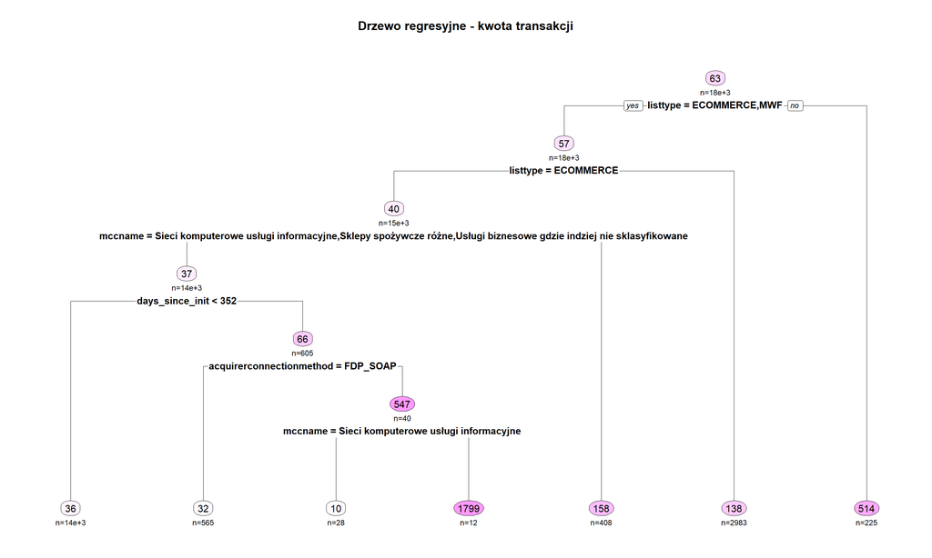

**Ważność zmiennych w drzewie na pełnych danych**

```
##                              [,1]
## listtype                 70079521
## mccname                  32642627
## type                     15682158
## days_since_init          12011501
## acquirerconnectionmethod  9899960
## expirymonth               2240308
## issuer                    2240308
## months_to_expire          2240308
```

**Reguły w drzewie na pełnych danych**

```
##  amount                                                                                                                                                                                                                                  cover
##      10 when listtype is ECOMMERCE & mccname is                                                                                Sieci komputerowe usługi informacyjne & days_since_init >= 352 & acquirerconnectionmethod is ECARD_REST      0%
##      32 when listtype is ECOMMERCE & mccname is Sieci komputerowe usługi informacyjne or Sklepy spożywcze różne or Usługi biznesowe gdzie indziej nie sklasyfikowane & days_since_init >= 352 & acquirerconnectionmethod is   FDP_SOAP      3%
##      36 when listtype is ECOMMERCE & mccname is Sieci komputerowe usługi informacyjne or Sklepy spożywcze różne or Usługi biznesowe gdzie indziej nie sklasyfikowane & days_since_init <  352                                              76%
##     138 when listtype is       MWF                                                                                                                                                                                                         17%
##     158 when listtype is ECOMMERCE & mccname is                                                                                         Restauracja or Ubezpieczenia                                                                        2%
##     514 when listtype is    PUBLIC                                                                                                                                                                                                          1%
##    1799 when listtype is ECOMMERCE & mccname is                                                                    Usługi biznesowe gdzie indziej nie sklasyfikowane & days_since_init >= 352 & acquirerconnectionmethod is ECARD_REST      0%
```

Analiza reguł wygenerowanych przez drzewo regresyjne ujawnia silną segmentację transakcji w zależności od sektora partnera oraz czasu trwania relacji.

Dominujący segment (Standardowe transakcje): Największa grupa, obejmująca aż 76% wszystkich obserwacji, to transakcje o relatywnie niskiej wartości (średnia 36 PLN). Dotyczy ona płatności w sektorze ECOMMERCE w standardowych kategoriach (usługi, sklepy spożywcze) realizowanych przez klientów o stażu krótszym niż rok (< 352 dni). Jest to bazowy profil klienta w analizowanym zbiorze.

Wpływ sektora działania partnera (listtype): Model wyraźnie wskazuje, że sektor partnera jest kluczowym czynnikiem różnicującym kwoty.

Dla sektora MWF (17% zbioru) średnia kwota transakcji wzrasta skokowo do 138 PLN.

Dla sektora PUBLIC (1% zbioru) model przewiduje jeszcze wyższe kwoty, na poziomie średnio 514 PLN.

Wykrycie anomalii / wartości skrajnych: Szczególną uwagę zwraca wyodrębnienie bardzo specyficznej reguły o znikomym pokryciu (0% ogółu, czyli pojedyncze przypadki), gdzie przewidywana kwota wynosi aż 1799 PLN. Model powiązał tę kwotę ze specyficzną kombinacją: długi staż klienta (> 352 dni) oraz sposób łączenia się (acquirerconnectionmethod) typu ECARD_REST. Sugeruje to, że w danych znajdują się pojedyncze transakcje o bardzo wysokich wartościach, które model próbuje “zapamiętać”, tworząc dla nich dedykowaną, bardzo szczegółową gałąź.

**Wartości ekstremalne**

Szczególną uwagę zwrócono na rozmieszczenie transakcji o najwyższych kwotach (powyżej 99. centyla). Analiza węzłów końcowych wykazała, że wartości ekstremalne nie tworzą jednorodnej grupy, lecz są rozproszone w wielu liściach. Poniższa tabela przedstawia liczbę transakcji ekstremalnych w poszczególnych węzłach końcowych drzewa:

```
## Ile w każdym węźle jest wartości ekstremalnych?
```

```
##  5  7  9 10 11 12 13
## 20  0  0  9  5 70 75
```

Z uwagi na fakt, że obecność pojedynczych, bardzo wysokich kwot zaburza średnią w liściach i utrudnia predykcję dla typowych transakcji, podjęto decyzję o budowie docelowego modelu na zbiorze ograniczonym do 99% populacji (`dane_reg_99`).

**Budowa modelu docelowego (bez outlierów)**

Zbudowano nowe drzewo regresyjne, wykluczając 1% najwyższych kwot. Model ten ma na celu precyzyjne odwzorowanie mechanizmów rządzących typowymi transakcjami.

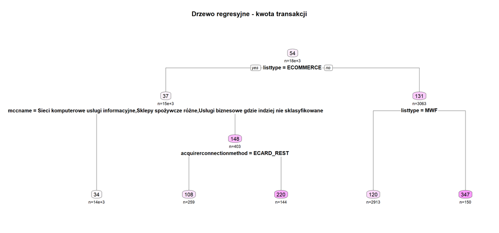

Struktura drzewa wskazuje, że kluczowymi czynnikami różnicującymi kwotę transakcji są: sektor działania partnera (`listtype`), kategoria sklepu (`mccname`) oraz metoda połączenia (`acquirerconnectionmethod`).

**Ważność zmiennych w drzewie na 99% populacji**

```
##                                 [,1]
## listtype                 29781148.17
## mccname                   5035857.07
## hour                      3333345.37
## acquirerconnectionmethod  1164958.49
## week_day                   928908.67
## week_part                  928908.67
## days_since_init            240354.32
## day_part                    48539.94
## months_to_expire            24269.97
```

Ranking ważności zmiennych potwierdza dominującą rolę sektora działania partnera (`listtype`) oraz kategorii MCC (`mccname`) oraz metody połączenia (`acquirerconnectionmethod`). Istotnym czynnikiem okazała się również godzina transakcji (`hour`), co sugeruje występowanie dobowych wzorców zakupowych.

**Reguły w drzewie na 99% populacji**

```
##  amount                                                                                                                                                                                                         cover
##      34 when listtype is ECOMMERCE & mccname is Sieci komputerowe usługi informacyjne or Sklepy spożywcze różne or Usługi biznesowe gdzie indziej nie sklasyfikowane                                              80%
##     108 when listtype is ECOMMERCE & mccname is                                                                                         Restauracja or Ubezpieczenia & acquirerconnectionmethod is ECARD_REST      1%
##     120 when listtype is       MWF                                                                                                                                                                                17%
##     220 when listtype is ECOMMERCE & mccname is                                                                                         Restauracja or Ubezpieczenia & acquirerconnectionmethod is   FDP_SOAP      1%
##     347 when listtype is    PUBLIC                                                                                                                                                                                 1%
```

Analiza reguł decyzyjnych pozwala na wyodrębnienie wyraźnych segmentów kwotowych, zależnych głównie od branży partnera (mccname) oraz jego sektora działania (listtype).

Segment podstawowy (Masowy): Dominującą grupę, obejmującą aż 80% wszystkich transakcji, stanowią płatności o niskiej średniej wartości (34 PLN). Dotyczą one sektora ECOMMERCE (`listtype`) w najpopularniejszych branżach (`mccname`), takich jak: usługi informacyjne, sklepy spożywcze oraz ogólne usługi biznesowe. Jest to najbardziej typowy profil transakcji w badanym zbiorze.

Segmenty o podwyższonej wartości (Wpływ sektora działania): Model wskazuje na silną zależność między sektorem działania partnera (`listtype`) a kwotą transakcji.

Dla sektora MWF, który stanowi drugą co do wielkości grupę (17% populacji), średnia przewidywana kwota wzrasta ponad trzykrotnie względem bazy, osiągając poziom 120 PLN.

Najwyższą średnią wartość (347 PLN) model przypisał do transakcji z sektora PUBLIC, choć stanowią one niewielki margines zbioru (1%).

Specyfika techniczna (Sposób łączenia): Wewnątrz sektora ECOMMERCE model wyodrębnił specyficzne branże (“Restauracja” oraz “Ubezpieczenia”), gdzie kluczowym czynnikiem różnicującym okazał się techniczny sposób łączenia się (acquirerconnectionmethod).

Użycie metody FDP_SOAP w tych branżach wiąże się ze średnią kwotą na poziomie 220 PLN.

Zastosowanie metody ECARD_REST wskazuje na niższą średnią – 108 PLN. Sugeruje to, że wybrana technologia integracji płatności może być powiązana z charakterystyką sprzedawanych usług (np. droższe polisy vs tańsze posiłki).

### Przycinanie drzewa

Aby uniknąć przeuczenia (overfitting), przeprowadzono procedurę przycinania drzewa. Wykorzystano metodę sprawdzania krzyżowego (cross-validation) do znalezienia optymalnego parametru złożoności `cp`.

**Finalna struktura modelu**

Po przycięciu uzyskano stabilny model, który generalizuje wiedzę o kwotach transakcji. Poniższy wykres prezentuje ostateczną postać drzewa regresyjnego.

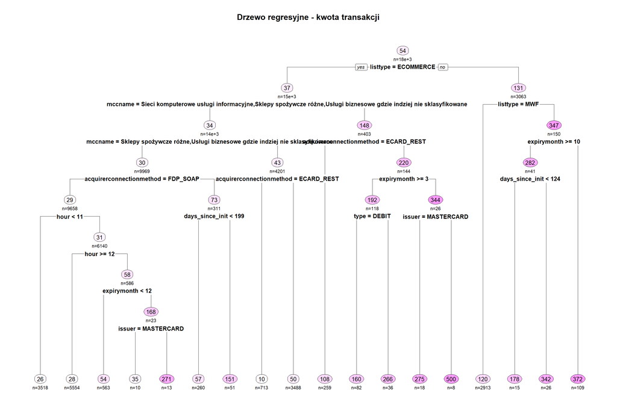

Ranking ważności zmiennych potwierdza dominującą rolę sektora działania partnera (`listtype`) oraz kategorii MCC (`mccname`). Istotnym czynnikiem okazała się również godzina transakcji (`hour`), co sugeruje występowanie dobowych wzorców zakupowych.

**Ważność zmiennych w drzewie przyciętym**

```
##                                 [,1]
## listtype                 29781148.17
## mccname                   5534511.20
## hour                      4600872.93
## acquirerconnectionmethod  2751315.29
## expirymonth               1102601.64
## week_day                  1026886.90
## days_since_init            972125.59
## week_part                  928908.67
## issuer                     594401.56
## type                       313359.53
## months_to_expire           295043.94
## expiryyear                 190439.00
## day_part                   101111.28
## card_origin                 75615.05
## expires_this_year           17063.72
```

**Reguły w drzewie przyciętym**

```
##  amount                                                                                                                                                                                                                                                                          cover
##      10 when listtype is ECOMMERCE & mccname is                                       Sieci komputerowe usługi informacyjne & acquirerconnectionmethod is ECARD_REST                                                                                                                4%
##      26 when listtype is ECOMMERCE & mccname is Sklepy spożywcze różne or Usługi biznesowe gdzie indziej nie sklasyfikowane & acquirerconnectionmethod is   FDP_SOAP                       & hour <  11                                                                            20%
##      28 when listtype is ECOMMERCE & mccname is Sklepy spożywcze różne or Usługi biznesowe gdzie indziej nie sklasyfikowane & acquirerconnectionmethod is   FDP_SOAP                       & hour >=       12                                                                      31%
##      35 when listtype is ECOMMERCE & mccname is Sklepy spożywcze różne or Usługi biznesowe gdzie indziej nie sklasyfikowane & acquirerconnectionmethod is   FDP_SOAP & expirymonth >= 11.5 & hour is 11 to 12                          & issuer is MASTERCARD                       0%
##      50 when listtype is ECOMMERCE & mccname is                                       Sieci komputerowe usługi informacyjne & acquirerconnectionmethod is   FDP_SOAP                                                                                                               20%
##      54 when listtype is ECOMMERCE & mccname is Sklepy spożywcze różne or Usługi biznesowe gdzie indziej nie sklasyfikowane & acquirerconnectionmethod is   FDP_SOAP & expirymonth <  11.5 & hour is 11 to 12                                                                       3%
##      57 when listtype is ECOMMERCE & mccname is Sklepy spożywcze różne or Usługi biznesowe gdzie indziej nie sklasyfikowane & acquirerconnectionmethod is ECARD_REST                                          & days_since_init <  199                                              1%
##     108 when listtype is ECOMMERCE & mccname is                                                Restauracja or Ubezpieczenia & acquirerconnectionmethod is ECARD_REST                                                                                                                1%
##     120 when listtype is       MWF                                                                                                                                                                                                                                                 17%
##     151 when listtype is ECOMMERCE & mccname is Sklepy spożywcze różne or Usługi biznesowe gdzie indziej nie sklasyfikowane & acquirerconnectionmethod is ECARD_REST                                          & days_since_init >= 199                                              0%
##     160 when listtype is ECOMMERCE & mccname is                                                Restauracja or Ubezpieczenia & acquirerconnectionmethod is   FDP_SOAP & expirymonth >=  2.5                                                                    & type is  DEBIT      0%
##     178 when listtype is    PUBLIC                                                                                                                                   & expirymonth >=  9.5                    & days_since_init <  124                                              0%
##     266 when listtype is ECOMMERCE & mccname is                                                Restauracja or Ubezpieczenia & acquirerconnectionmethod is   FDP_SOAP & expirymonth >=  2.5                                                                    & type is CREDIT      0%
##     271 when listtype is ECOMMERCE & mccname is Sklepy spożywcze różne or Usługi biznesowe gdzie indziej nie sklasyfikowane & acquirerconnectionmethod is   FDP_SOAP & expirymonth >= 11.5 & hour is 11 to 12                          & issuer is       VISA                       0%
##     275 when listtype is ECOMMERCE & mccname is                                                Restauracja or Ubezpieczenia & acquirerconnectionmethod is   FDP_SOAP & expirymonth <   2.5                                             & issuer is MASTERCARD                       0%
##     342 when listtype is    PUBLIC                                                                                                                                   & expirymonth >=  9.5                    & days_since_init >= 124                                              0%
##     372 when listtype is    PUBLIC                                                                                                                                   & expirymonth <   9.5                                                                                          1%
##     500 when listtype is ECOMMERCE & mccname is                                                Restauracja or Ubezpieczenia & acquirerconnectionmethod is   FDP_SOAP & expirymonth <   2.5                                             & issuer is       VISA                       0%
```

Model finalny skutecznie zgeneralizował dane, wyodrębniając trzy główne profile transakcyjne w oparciu o sektor (`listtype`), branżę (`mccname`) oraz technologię połączenia (`acquirerconnectionmethod`).

Segment średni (Sektor MWF): Bardzo stabilna i liczna grupa (17% populacji) to transakcje z sektora MWF. Model nie wymagał tu dodatkowych podziałów – sam fakt przynależności do tego sektora determinuje przewidywaną kwotę na poziomie 120 PLN.

Dla sektora PUBLIC, gdzie średnie sięgają 342–372 PLN.

### Ewaluacja modeli

Ocenę jakości predykcji przeprowadzono na niezależnych zbiorach walidacyjnych (`dane_wal_reg_full` oraz `dane_wal_reg_99`), ograniczonym do zakresu typowych transakcji. Pozwala to na rzetelne sprawdzenie błędu generalizacji modelu.

Porównanie modeli regresyjnych

| Model | MSE | RMSE | R2 |
| --- | --- | --- | --- |
| 1. Pełny (z outlierami) | 13119.664 | 114.54110 | 0.3503725 |
| 2. Bez outlierów (przed przycięciem) | 2528.349 | 50.28269 | 0.4269962 |
| 3. Bez outlierów (po przycięciu/optymalny) | 2353.499 | 48.51288 | 0.4666227 |

Przeprowadzona analiza porównawcza wykazała kluczowy wpływ wartości ekstremalnych na jakość predykcji.

## Predykcja modelowanych zmiennych na danych testowych

W celu maksymalizacji zdolności generalizacji modelu, ostateczne **drzewo regresyjne** zostało douczone na połączonym zbiorze danych (treningowym oraz walidacyjnym), przy zachowaniu optymalnego parametru złożoności (`cp`) wyznaczonego w procesie walidacji krzyżowej.

Proces wyznaczania wartości zmiennej celu amount dla zbioru testowego przeprowadzono dwutorowo, uwzględniając specyfikę typów transakcji:

- Transakcje rekurencyjne: Dla obserwacji zidentyfikowanych jako kontynuacja subskrypcji, predykcja kwoty została wygenerowana przy użyciu wytrenowanego modelu drzewa regresyjnego. Pozwoliło to na uwzględnienie nieliniowych zależności między cechami transakcji a jej wartością.
- Transakcje inicjujące: W przypadku transakcji rozpoczynających cykl, zastosowano podejście oparte na estymatorze statystycznym. Przypisano im wartość mediany obliczoną na podstawie transakcji inicjujących ze zbioru uczącego. Podejście to wynika z obserwowanej niskiej wariancji kwot weryfikacyjnych i startowych, co czyni medianę stabilnym i odpornym na wartości odstające predyktorem dla tej grupy.

W obszarze **klasyfikacji** zastosowano tożsamą strategię. Ostateczny model drzewa decyzyjnego został ponownie przeliczony na połączonym zbiorze danych (treningowym i walidacyjnym), przy zachowaniu parametru przycięcia (`cp`) wynikającego z przyjętej wcześniej reguły.

Procedura wyznaczania statusu dla zbioru testowego przebiegała według następujących reguł:

- Transakcje rekurencyjne: Decyzja o przypisaniu klasy (sukces lub porażka) została podjęta przez wytrenowany model drzewa, na podstawie cech transakcji.
- Transakcje inicjujące: Zgodnie z założeniem, transakcje typu INIT (służące do rejestracji karty) w analizowanym zbiorze traktowane są jako poprawne technicznie. Przypisano im deterministycznie status sukces, co eliminuje ryzyko błędnej klasyfikacji przez model uczony na specyfice płatności odnawialnych.
- Wypełnianie braków: W przypadku obserwacji nietypowych, dla których model nie mógł wygenerować jednoznacznej ścieżki (np. braki danych w kluczowych atrybutach), przypisano klasę większościową (`sukces`).

Kompletne wyniki predykcji zapisano w obiekcie predykcje_testowa w formacie .RData, zachowując integralność wymiarową z dostarczonym szablonem.

```
## Plik 'predykcje_testowa.RData' zapisany poprawnie.
##
## porażka  sukces
##     846   14339
##    Min. 1st Qu.  Median    Mean 3rd Qu.    Max.
##   10.03   28.78   28.78   47.08   50.31  346.77
```